# Practical Machine Learning Prediction Assignment

Karishma Pandey

# Background

Using devices such as Jawbone Up, Nike FuelBand, and Fitbit, it is possible to collect large amounts of data about personal activity. This project uses accelerometer measurements collected from the belt, forearm, arm, and dumbbell of six participants performing barbell lifts in five different ways.

The objective of this project is to predict the manner in which the exercise was performed. The response variable is `classe`, with five possible classes: A, B, C, D, and E.

# Data

The training dataset contains observations collected from accelerometers attached to different parts of the participants’ bodies. The testing dataset contains 20 observations for which the exercise classification must be predicted.

The training and testing datasets were downloaded from the sources provided in the course project instructions.

# Loading Required Libraries

```r
library(caret)
library(randomForest)

set.seed(12345)
```

# Loading the Data

```r
training <- read.csv(
  "pml-training.csv",
  na.strings = c("", "NA", "#DIV/0!")
)

testing <- read.csv(
  "pml-testing.csv",
  na.strings = c("", "NA", "#DIV/0!")
)

dim(training)
```

```
## [1] 19622   160
```

```r
dim(testing)
```

```
## [1]  20 160
```

# Exploratory Data Analysis

The variable `classe` is the outcome variable that we want to predict. It represents the manner in which the exercise was performed.

```r
table(training$classe)
```

```
##
##    A    B    C    D    E
## 5580 3797 3422 3216 3607
```

# Data Cleaning

The dataset contains several variables with a large number of missing values. Variables containing more than 60% missing values are removed. Near-zero variance variables are also removed because they provide little useful information for classification.

The outcome variable `classe` is excluded from the predictors. Identification and time-related variables are also removed.

```r
# Separate the outcome variable from the predictors
training_predictors <- training[, setdiff(names(training), "classe")]

# Calculate the proportion of missing values in each predictor
missing_fraction <- sapply(
  training_predictors,
  function(x) mean(is.na(x))
)

# Keep predictors with less than 60% missing values
keep_columns <- names(
  missing_fraction[missing_fraction < 0.60]
)

# Make sure only variables available in both datasets are selected
keep_columns <- intersect(
  keep_columns,
  names(testing)
)

# Create cleaned datasets
training_clean <- training[, c(keep_columns, "classe")]
testing_clean <- testing[, keep_columns]

# Remove near-zero variance predictors
nzv <- nearZeroVar(training_clean[, keep_columns])

if (length(nzv) > 0) {
  keep_columns <- keep_columns[-nzv]
}

# Recreate cleaned datasets after NZV removal
training_clean <- training[, c(keep_columns, "classe")]
testing_clean <- testing[, keep_columns]

# Remove the first seven identification/time-related variables
training_clean <- training_clean[, -c(1:7)]
testing_clean <- testing_clean[, -c(1:7)]

# Check dimensions
dim(training_clean)
```

```
## [1] 19622    52
```

```r
dim(testing_clean)
```

```
## [1] 20 51
```

```r
sum(is.na(training_clean))
```

```
## [1] 0
```

```r
sum(is.na(testing_clean))
```

```
## [1] 0
```

# Training and Validation Split

The cleaned training data are divided into a training set and a validation set. Approximately 70% of the observations are used for model training and the remaining 30% are reserved for validation. The validation data are not used to fit the model, allowing its performance to be evaluated on previously unseen observations.

```r
set.seed(12345)

train_index <- createDataPartition(
  training_clean$classe,
  p = 0.70,
  list = FALSE
)

train_data <- training_clean[train_index, ]

validation_data <- training_clean[-train_index, ]

dim(train_data)
```

```
## [1] 13737    52
```

```r
dim(validation_data)
```

```
## [1] 5885   52
```

# Random Forest Model

A Random Forest classifier is used because the response variable `classe` is categorical and the dataset contains multiple sensor-based predictor variables. Five-fold cross-validation is used during model training to assess model performance across different subsets of the training data.

```r
set.seed(12345)

control <- trainControl(
  method = "cv",
  number = 5
)

rf_model <- train(
  classe ~ .,
  data = train_data,
  method = "rf",
  trControl = control,
  ntree = 300
)

rf_model
```

```
## Random Forest
##
## 13737 samples
##    51 predictor
##     5 classes: 'A', 'B', 'C', 'D', 'E'
##
## No pre-processing
## Resampling: Cross-Validated (5 fold)
## Summary of sample sizes: 10990, 10990, 10989, 10991, 10988
## Resampling results across tuning parameters:
##
##   mtry  Accuracy   Kappa
##    2    0.9907546  0.9883033
##   26    0.9917738  0.9895935
##   51    0.9874786  0.9841595
##
## Accuracy was used to select the optimal model using the largest value.
## The final value used for the model was mtry = 26.
```

# Model Evaluation

The trained Random Forest model is evaluated on the validation dataset, which was not used during model training.

```r
validation_predictions <- predict(
  rf_model,
  newdata = validation_data
)

# Ensure predictions and reference values have identical factor levels
validation_predictions <- factor(
  validation_predictions,
  levels = levels(factor(training_clean$classe))
)

validation_actual <- factor(
  validation_data$classe,
  levels = levels(factor(training_clean$classe))
)

confusionMatrix(
  validation_predictions,
  validation_actual
)
```

```
## Confusion Matrix and Statistics
##
##           Reference
## Prediction    A    B    C    D    E
##          A 1672    7    0    0    0
##          B    1 1129    7    0    0
##          C    1    3 1016    7    0
##          D    0    0    3  956    1
##          E    0    0    0    1 1081
##
## Overall Statistics
##
##                Accuracy : 0.9947
##                  95% CI : (0.9925, 0.9964)
##     No Information Rate : 0.2845
##     P-Value [Acc > NIR] : < 2.2e-16
##
##                   Kappa : 0.9933
##
##  Mcnemar's Test P-Value : NA
##
## Statistics by Class:
##
##                      Class: A Class: B Class: C Class: D Class: E
## Sensitivity            0.9988   0.9912   0.9903   0.9917   0.9991
## Specificity            0.9983   0.9983   0.9977   0.9992   0.9998
## Pos Pred Value         0.9958   0.9930   0.9893   0.9958   0.9991
## Neg Pred Value         0.9995   0.9979   0.9979   0.9984   0.9998
## Prevalence             0.2845   0.1935   0.1743   0.1638   0.1839
## Detection Rate         0.2841   0.1918   0.1726   0.1624   0.1837
## Detection Prevalence   0.2853   0.1932   0.1745   0.1631   0.1839
## Balanced Accuracy      0.9986   0.9948   0.9940   0.9954   0.9994
```

## Expected Out-of-Sample Error

The validation accuracy is used to estimate the expected out-of-sample error. The error rate is calculated as one minus the validation accuracy.

```r
accuracy <- confusionMatrix(
  validation_predictions,
  validation_actual
)$overall["Accuracy"]

out_of_sample_error <- 1 - accuracy

accuracy
```

```
##  Accuracy
## 0.9947324
```

```r
out_of_sample_error
```

```
##   Accuracy
## 0.00526763
```

# Variable Importance

Variable importance is examined to identify the predictor variables that contributed most to the Random Forest classification.

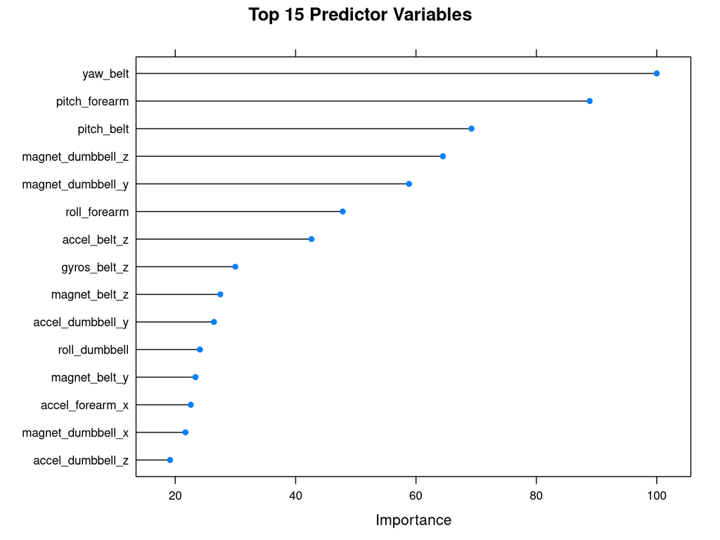

```r
plot(
  varImp(rf_model),
  top = 15,
  main = "Top 15 Predictor Variables"
)
```

# Final Model

After evaluating the Random Forest model on the validation data, the final model is trained using the complete cleaned training dataset. This allows the model to use all available labeled observations before making predictions on the 20 test cases.

```r
set.seed(12345)

final_model <- train(
  classe ~ .,
  data = training_clean,
  method = "rf",
  trControl = trainControl(method = "none"),
  tuneGrid = data.frame(mtry = 26),
  ntree = 300
)

final_model
```

```
## Random Forest
##
## 19622 samples
##    51 predictor
##     5 classes: 'A', 'B', 'C', 'D', 'E'
##
## No pre-processing
## Resampling: None
```

# Prediction of the Test Cases

The final Random Forest model is used to predict the exercise classification for the 20 observations in the provided testing dataset.

```r
final_predictions <- predict(
  final_model,
  newdata = testing_clean
)

final_predictions
```

```
##  [1] B A B A A E D B A A B C B A E E A B B B
## Levels: A B C D E
```

```r
prediction_table <- data.frame(
  Problem_ID = 1:20,
  Prediction = final_predictions
)

prediction_table
```

```
##    Problem_ID Prediction
## 1           1          B
## 2           2          A
## 3           3          B
## 4           4          A
## 5           5          A
## 6           6          E
## 7           7          D
## 8           8          B
## 9           9          A
## 10         10          A
## 11         11          B
## 12         12          C
## 13         13          B
## 14         14          A
## 15         15          E
## 16         16          E
## 17         17          A
## 18         18          B
## 19         19          B
## 20         20          B
```

# Conclusion

A Random Forest classification model was developed to predict the manner in which participants performed the weight lifting exercise. The data were cleaned by removing variables with excessive missing values, near-zero variance variables, and identification-related variables.

The model was trained using five-fold cross-validation. The best model used an `mtry` value of 26 and achieved a validation accuracy of approximately 99.47%. The corresponding estimated out-of-sample error was approximately 0.53%.

The final Random Forest model was then trained using the complete cleaned training dataset. This final model was used to predict the exercise classification for the 20 observations in the provided testing dataset.